# Data Analysis

John Cornelison

10/16/2023

### Data Analysis and Visualizations

### General Clinic Information

There are 35999 rows in the vet clinic data set. There are 32534 unique vet clinics. The total number of clinics with hours is 23,637. There were some duplicate instances where a clinic would have multiple clinics at the same location. Sometimes it was because of different specialty clinics were offered at the location, other times it was because a veterinarian was being counted as a clinic. I removed the veterinarians in these instances. This brought our total number of clinics with hours down to 23,525.

To start, lets take a look at the count of Open times for each day. Keep in mind, for the first four graphics, only the hour is reported. 7:45 = 7.

### Open Times

Count of Open times by Day

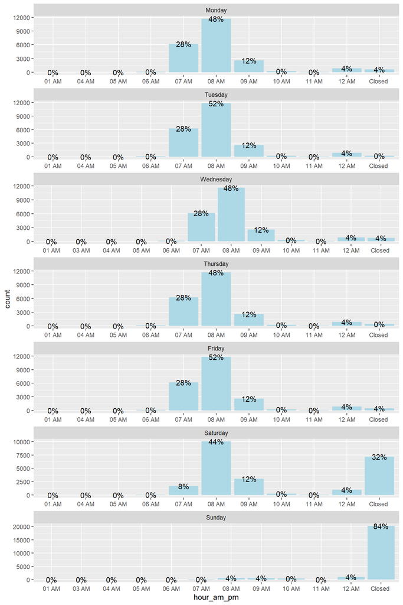

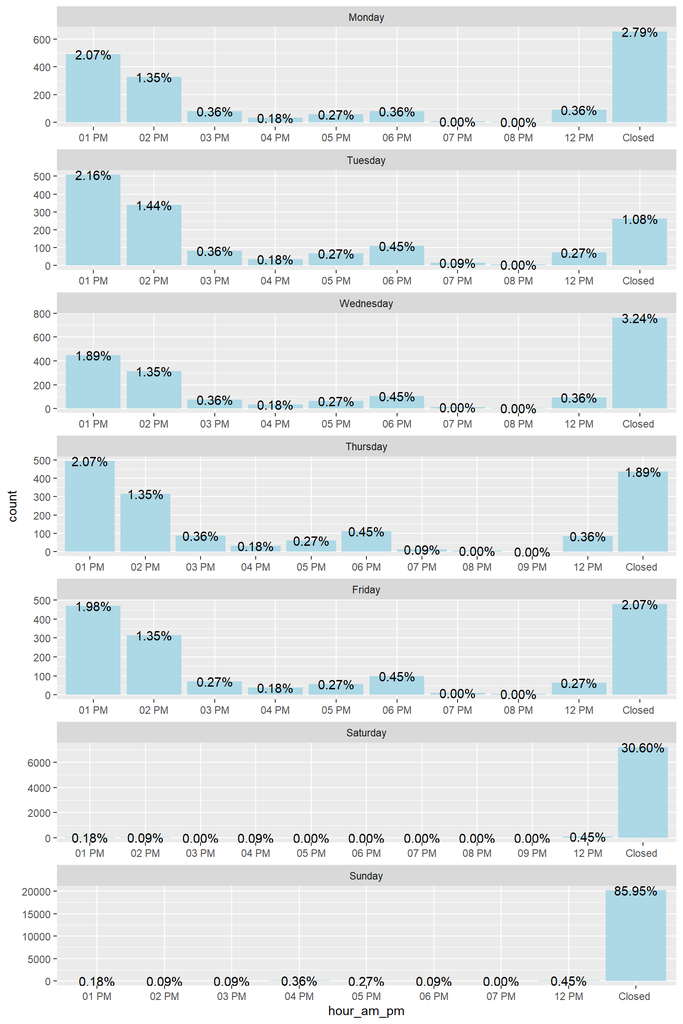

- Monday, 88% of clinics open between 7 and 9:59 am
- Tuesday, 92% of clinics open between 7 and 9:59 am
- Wednesday, 88% of clinics open between 7 and 9:59 am
- Thursday, 88% of clinics open between 7 and 9:59 am
- Friday, 92% of clinics open between 7 and 9:59 am
- Saturday, 64% of clinics open between 7 and 9:59 am
- Sunday, 84% of clinics are CLOSED

### Close Times

Count of Close times by Day

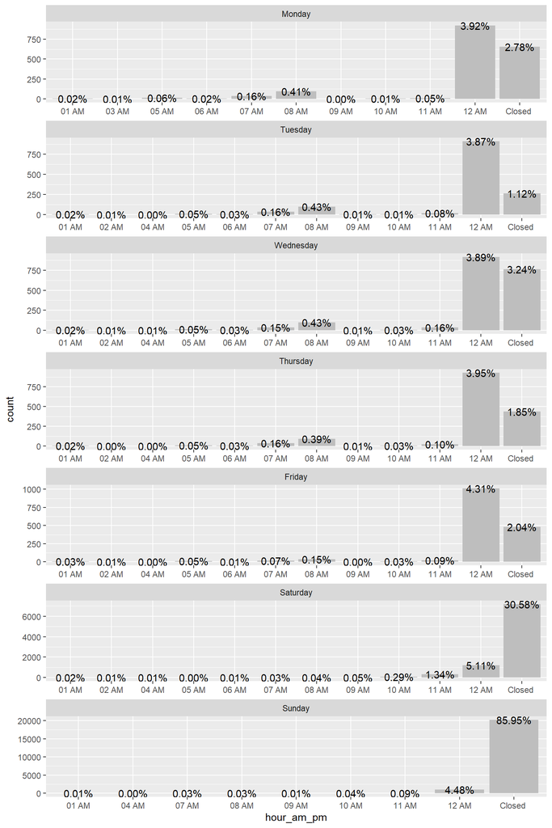

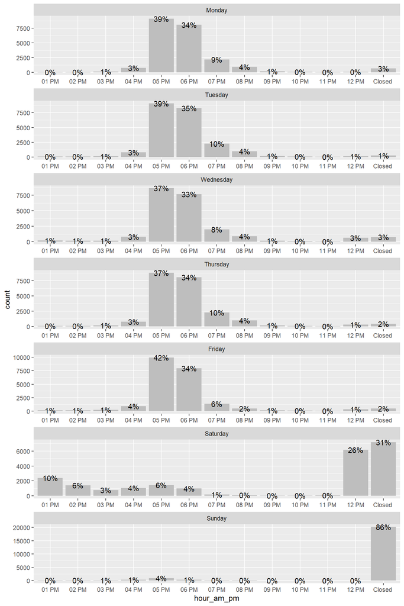

- Monday, 82% Close between 5 and 7:59 PM
- Tuesday, 84% Close between 5 and 7:59 PM
- Wednesday, 78% Close between 5 and 7:59 PM
- Thursday, 81% Close between 5 and 7:59 PM
- Friday, 82% Close between 5 and 7:59 PM
- Saturday, 26% Close between 12 PM and 12:59 PM
- Sunday, 86% of clinics are CLOSED

### Table of Open and Close hours for different days of the Week

For week days, about 80% of the clinics open between 7 and 9 and about 80% close between 5 - 8 PM

Opening Times for Weekdays

| Time | Monday Percent | Tuesday Percent | Wednesday Percent | Thursday Percent | Friday Percent |
| --- | --- | --- | --- | --- | --- |
| 08:00 AM | 45.01 | 45.55 | 44.74 | 45.13 | 45.44 |
| 07:30 AM | 15.33 | 15.51 | 15.12 | 15.45 | 15.32 |
| 09:00 AM | 10.67 | 10.79 | 10.68 | 10.72 | 10.95 |
| 07:00 AM | 10.44 | 10.72 | 10.46 | 10.68 | 10.52 |
| 08:30 AM | 4.65 | 4.72 | 4.55 | 4.67 | 4.72 |
| 12:00 AM | 3.76 | 3.67 | 3.67 | 3.69 | 3.76 |
| Closed | 2.78 | 1.12 | 3.24 | 1.85 | 2.04 |
| 01:00 PM | 1.34 | 1.38 | 1.25 | 1.34 | 1.28 |
| 02:00 PM | 1.23 | 1.27 | 1.21 | 1.19 | 1.19 |
| 10:00 AM | 0.88 | 1.05 | 1.12 | 1.05 | 0.95 |

Closing Times for Weekdays

| Time | Monday Percent | Tuesday Percent | Wednesday Percent | Thursday Percent | Friday Percent |
| --- | --- | --- | --- | --- | --- |
| 06:00 PM | 33.14 | 33.84 | 31.55 | 33.03 | 32.87 |
| 05:00 PM | 24.94 | 24.71 | 23.81 | 23.99 | 28.30 |
| 05:30 PM | 13.68 | 13.74 | 12.92 | 13.29 | 13.89 |
| 07:00 PM | 8.60 | 9.05 | 7.86 | 8.99 | 5.50 |
| 08:00 PM | 3.93 | 4.04 | 3.78 | 4.22 | 2.07 |
| 12:00 AM | 3.91 | 3.87 | 3.89 | 3.94 | 4.30 |
| Closed | 2.78 | 1.12 | 3.24 | 1.85 | 2.04 |
| 04:00 PM | 2.19 | 2.37 | 2.34 | 2.25 | 2.98 |
| 06:30 PM | 1.26 | 1.23 | 1.07 | 1.30 | 0.90 |
| 04:30 PM | 0.99 | 1.02 | 1.04 | 1.00 | 1.01 |

For Saturday, most of the open hours open at 8 or 9 and close at 12, 1, or 2 PM

Opening Times for Saturday

| Time | Saturday Count | Saturday Percent |
| --- | --- | --- |
| 08:00 AM | 9159 | 38.93 |
| Closed | 7195 | 30.58 |
| 09:00 AM | 3003 | 12.77 |
| 12:00 AM | 981 | 4.17 |
| 08:30 AM | 865 | 3.68 |
| 07:30 AM | 851 | 3.62 |
| 07:00 AM | 808 | 3.43 |
| 10:00 AM | 253 | 1.08 |
| 12:00 PM | 97 | 0.41 |
| 09:30 AM | 45 | 0.19 |

Closing Times for Saturday

| Time | Saturday Count | Saturday Percent |
| --- | --- | --- |
| Closed | 7195 | 30.58 |
| 12:00 PM | 5960 | 25.33 |
| 01:00 PM | 2329 | 9.90 |
| 02:00 PM | 1383 | 5.88 |
| 05:00 PM | 1365 | 5.80 |
| 12:00 AM | 1196 | 5.08 |
| 04:00 PM | 1009 | 4.29 |
| 06:00 PM | 978 | 4.16 |
| 03:00 PM | 742 | 3.15 |
| 12:30 PM | 215 | 0.91 |

For Sunday, 85% are closed. The next most common hours refer to 24 hour clinics

Opening Times for Sunday

| Time | Sunday Count | Sunday Percent |
| --- | --- | --- |
| Closed | 20220 | 85.95 |
| 12:00 AM | 1027 | 4.37 |
| 09:00 AM | 637 | 2.71 |
| 08:00 AM | 585 | 2.49 |
| 10:00 AM | 404 | 1.72 |
| 12:00 PM | 113 | 0.48 |
| 07:00 AM | 98 | 0.42 |
| 04:00 PM | 75 | 0.32 |
| 05:00 PM | 58 | 0.25 |
| 11:00 AM | 58 | 0.25 |

Closing Times for Sunday

| Time | Sunday Count | Sunday Percent |
| --- | --- | --- |
| Closed | 20220 | 85.95 |
| 12:00 AM | 1055 | 4.48 |
| 05:00 PM | 820 | 3.49 |
| 06:00 PM | 327 | 1.39 |
| 04:00 PM | 286 | 1.22 |
| 03:00 PM | 127 | 0.54 |
| 02:00 PM | 112 | 0.48 |
| 08:00 PM | 91 | 0.39 |
| 07:00 PM | 82 | 0.35 |
| 01:00 PM | 81 | 0.34 |

### Hours of Operation Box Plot

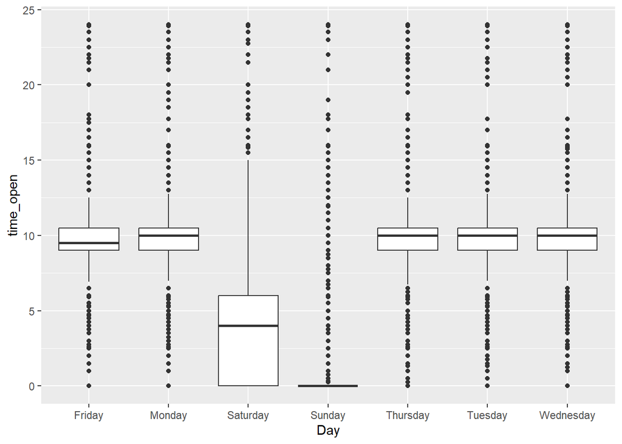

Summary of total weekly hours and standard deviation

```
##    Min. 1st Qu.  Median    Mean 3rd Qu.    Max.
##     2.0    45.0    51.5    55.5    59.0   168.0
```

```
## [1] "Standard Deviation"
```

```
## [1] 25.74647
```

Most Clinics only offer about 60 hours or less of operation for the entire week.

summary of total weekend hours and standard deviation

```
##    Min. 1st Qu.  Median    Mean 3rd Qu.    Max.
##   0.000   0.000   4.000   6.529   6.500  48.000
```

```
## [1] "Standard Deviation"
```

```
## [1] 10.06075
```

Most Clinics only offer about 6 and a half hours or less of operation on the weekend.

### Hours of Clinics by State

```
## To install your API key for use in future sessions, run this function with `install = TRUE`.
```

```
## Using the PL 94-171 Redistricting Data Summary File
```

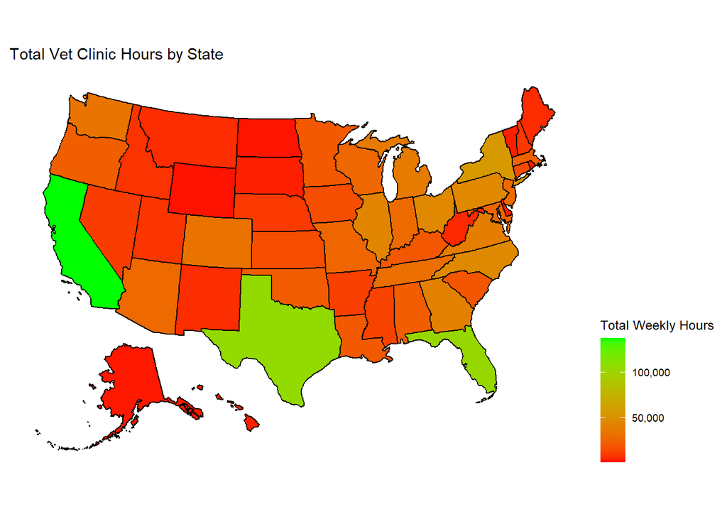

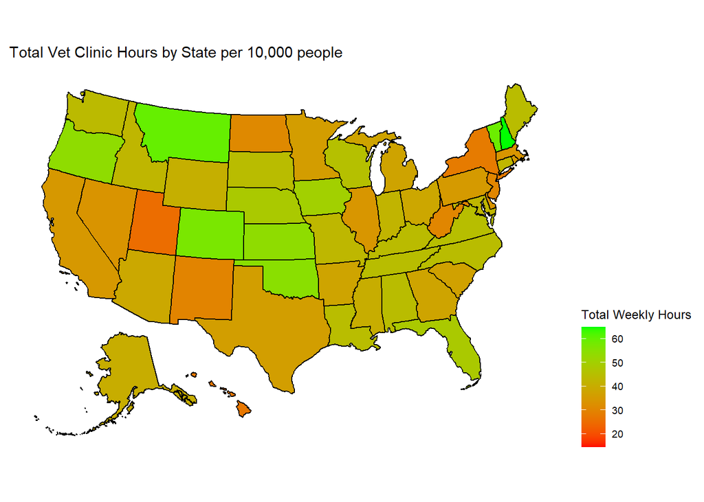

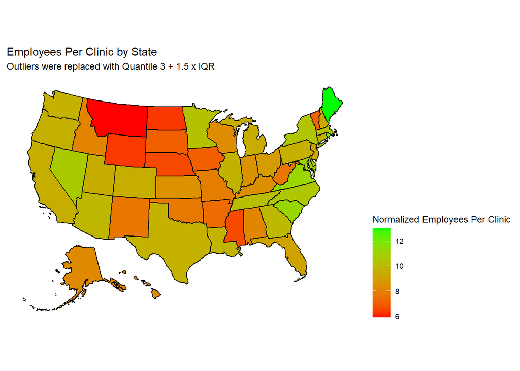

### Clinics by Type Breakdown

Definitions of Clinic Types

*Normal Clinics*: A normal clinic is defined as any clinic that is open at least 1 day for at least 1 consecutive hour between 8:00 AM and 5:00 PM Monday through Friday.

*Limbo Clinics*: A Clinic that offers hours after 5:00 PM on at least 1 day, but not for a consecutive hour after 6:00 PM.

*Outside Normal Hours Clinic*: An Outside Normal Hours Clinic is defined as any clinic that is open at least 1 day for at least 1 consecutive hour after 6:00 PM and before 8:00 PM on weekdays, after 6:00 AM and before 8:00 AM on weekdays, or between 8:00 AM and 5:00 PM on the weekends.

*Emergency Clinics*: An Emergency Clinic is defined as any clinic that is open at least 1 day for at least 1 consecutive hour after 8:00 PM and before 6:00 AM on weekdays, after 5:00 PM on weekends, and before 8:00 AM on weekends.

*24 Hour Clinic*: A 24 hour clinics is defined as any clinic that is open at least 1 day for more than 23 hours

You will notice that I used days count metric for looking at hours of operation

### Table of Clinic Type Counts

| Var1 | Freq |
| --- | --- |
| 24 Hour Clinic | 1050 |
| Emergency Clinic | 1666 |
| Limbo Time Clinic | 2715 |
| Normal Clinic | 3162 |
| Outside Normal Hours Clinic | 14932 |

### Normal Hour Clinics

Top Ten Normal Clinic Hours Operation

| values | Days Count | Percent |
| --- | --- | --- |
| 08:00 AM-05:00 PM | 6986 | 46.08% |
| 09:00 AM-05:00 PM | 2335 | 15.40% |
| 07:30 AM-05:00 PM | 908 | 5.99% |
| 08:30 AM-05:00 PM | 787 | 5.19% |
| 08:00 AM-04:00 PM | 718 | 4.74% |
| 01:00 PM-05:00 PM | 395 | 2.61% |
| 09:00 AM-04:00 PM | 324 | 2.14% |
| 08:00 AM-04:30 PM | 264 | 1.74% |
| 02:00 PM-05:00 PM | 238 | 1.57% |
| 08:00 AM-12:00 PM | 217 | 1.43% |

### Limbo Time Clinics

Limbo Time clinics will include normal hours as well because they may have only 1 or 2 days that offer limbo time hours, but the other days are normal.

Top Ten Limbo Clinic Hours Operation

| values | Days Count | Percent |
| --- | --- | --- |
| 08:00 AM-06:00 PM | 3828 | 32.02% |
| 08:00 AM-05:30 PM | 2139 | 17.89% |
| 07:30 AM-05:30 PM | 1660 | 13.89% |
| 07:30 AM-06:00 PM | 1220 | 10.21% |
| 09:00 AM-06:00 PM | 723 | 6.05% |
| 08:30 AM-05:30 PM | 498 | 4.17% |
| 08:30 AM-06:00 PM | 270 | 2.26% |
| 09:00 AM-05:30 PM | 212 | 1.77% |
| 01:30 PM-05:30 PM | 168 | 1.41% |
| 02:00 PM-06:00 PM | 142 | 1.19% |

### Outside Normal Hour Clinics

Outside Normal Hour Clinics may also offer normal hours and limbo hours.

Top Ten Outside Normal Hour Clinics Weekday Hours of Operation

| values | Days Count | Percent |
| --- | --- | --- |
| 07:00 AM-06:00 PM | 3816 | 20.99% |
| 08:00 AM-07:00 PM | 3081 | 16.95% |
| 07:00 AM-07:00 PM | 1836 | 10.10% |
| 08:00 AM-08:00 PM | 1757 | 9.66% |
| 07:30 AM-07:00 PM | 1212 | 6.67% |
| 09:00 AM-07:00 PM | 1034 | 5.69% |
| 07:00 AM-05:30 PM | 790 | 4.35% |
| 07:00 AM-05:00 PM | 776 | 4.27% |
| 07:30 AM-08:00 PM | 482 | 2.65% |
| 07:00 AM-08:00 PM | 467 | 2.57% |

Top Ten Outside Normal Hour Clinics Saturday Hours of Operation

| Saturday_Open_Close | Days Count | Percent |
| --- | --- | --- |
| 08:00 AM-12:00 PM | 4127 | 30.13% |
| 08:00 AM-01:00 PM | 1243 | 9.07% |
| 09:00 AM-12:00 PM | 842 | 6.15% |
| 08:00 AM-02:00 PM | 772 | 5.64% |
| 08:00 AM-05:00 PM | 684 | 4.99% |
| 09:00 AM-01:00 PM | 658 | 4.80% |
| 08:00 AM-04:00 PM | 550 | 4.02% |
| 08:00 AM-06:00 PM | 540 | 3.94% |
| 07:30 AM-12:00 PM | 401 | 2.93% |
| 08:00 AM-03:00 PM | 368 | 2.69% |

Top Ten Outside Normal Hour Clinics Sunday Hours of Operation

| Sunday_Open_Close | Days Count | Percent |
| --- | --- | --- |
| 09:00 AM-05:00 PM | 230 | 15.62% |
| 10:00 AM-05:00 PM | 153 | 10.39% |
| 08:00 AM-05:00 PM | 112 | 7.61% |
| 08:00 AM-04:00 PM | 90 | 6.11% |
| 08:00 AM-06:00 PM | 87 | 5.91% |
| 09:00 AM-04:00 PM | 66 | 4.48% |
| 10:00 AM-04:00 PM | 54 | 3.67% |
| 09:00 AM-06:00 PM | 38 | 2.58% |
| 10:00 AM-02:00 PM | 37 | 2.51% |
| 09:00 AM-02:00 PM | 37 | 2.51% |

### Emergency Clinics

It is possible for emergency clinics to also offer normal, limbo, and outside normal hours throughout the week.

Top Ten emergency Clinics Weekday Hours of Operation

| values | Days Count | Percent |
| --- | --- | --- |
| 08:00 AM-09:00 PM | 257 | 10.12% |
| 08:00 AM-12:00 AM | 240 | 9.45% |
| 07:00 AM-09:00 PM | 212 | 8.35% |
| 08:00 AM-10:00 PM | 175 | 6.89% |
| 07:00 AM-10:00 PM | 158 | 6.22% |
| 09:00 AM-09:00 PM | 151 | 5.95% |
| 12:00 PM-12:00 AM | 97 | 3.82% |
| 07:00 AM-12:00 AM | 91 | 3.58% |
| 07:30 AM-09:00 PM | 81 | 3.19% |
| 06:00 PM-08:00 AM | 60 | 2.36% |

Top Ten emergency Clinics Saturday Hours of Operation

| Saturday_Open_Close | Days Count | Percent |
| --- | --- | --- |
| 07:00 AM-06:00 PM | 185 | 13.53% |
| 07:00 AM-12:00 PM | 166 | 12.14% |
| 07:00 AM-05:00 PM | 123 | 9.00% |
| 08:00 AM-12:00 AM | 122 | 8.92% |
| 08:00 AM-07:00 PM | 66 | 4.83% |
| 07:00 AM-01:00 PM | 61 | 4.46% |
| 07:00 AM-02:00 PM | 58 | 4.24% |
| 07:00 AM-07:00 PM | 55 | 4.02% |
| 08:00 AM-08:00 PM | 49 | 3.58% |
| 07:00 AM-04:00 PM | 38 | 2.78% |

Top emergency Clinics Sunday Hours of Operation

| Sunday_Open_Close | Days Count | Percent |
| --- | --- | --- |
| 08:00 AM-08:00 PM | 34 | 8.59% |
| 08:00 AM-12:00 AM | 20 | 5.05% |
| 08:00 AM-07:00 PM | 19 | 4.80% |
| 12:00 PM-12:00 AM | 18 | 4.55% |
| 10:00 AM-08:00 PM | 17 | 4.29% |
| 07:00 AM-06:00 PM | 16 | 4.04% |
| 09:00 AM-07:00 PM | 16 | 4.04% |
| 07:00 AM-07:00 PM | 15 | 3.79% |
| 08:00 AM-10:00 PM | 15 | 3.79% |
| 07:00 AM-05:00 PM | 14 | 3.54% |

### Chi Square Test + Cramer V

For this Chi Square Test, I tested the SVI Index with the type of clinics. Each RPL Theme was dividing into 5 groups, ranging from “Very Vulnerable” to “Very Secure”. Each P-value was significant, but the size of the groups could be playing a factor into that. Each of the cramer v values, which measures the association between two variables. 0 is no association and 1 is perfect association. Our values show there is a very weak association.

| RPL_Theme | P_value | Cramer_V |
| --- | --- | --- |
| Socioeconomic Status | 0 | 0.0352754 |
| Household Characteristics | 0 | 0.0266472 |
| Racial & Ethnic Minority Status | 0 | 0.0556125 |
| Housing Type & Transportation | 0 | 0.0374298 |
| All Themes | 0 | 0.0322088 |

#### Model To Explain Clinic Classification

First, I wanted to see if whether median household income by census tract was associated with the type of clinic. So, created some box plots. From the first box plot, limbo and normal clinics have a slightly lower median income, but all types of clinics are roughly the same. Normal, Limbo, and outside normal have more high income outliers than 24 hour and emergency clinics.

When replacing the outliers, the clinic types still have roughly similar distribution of median household income.

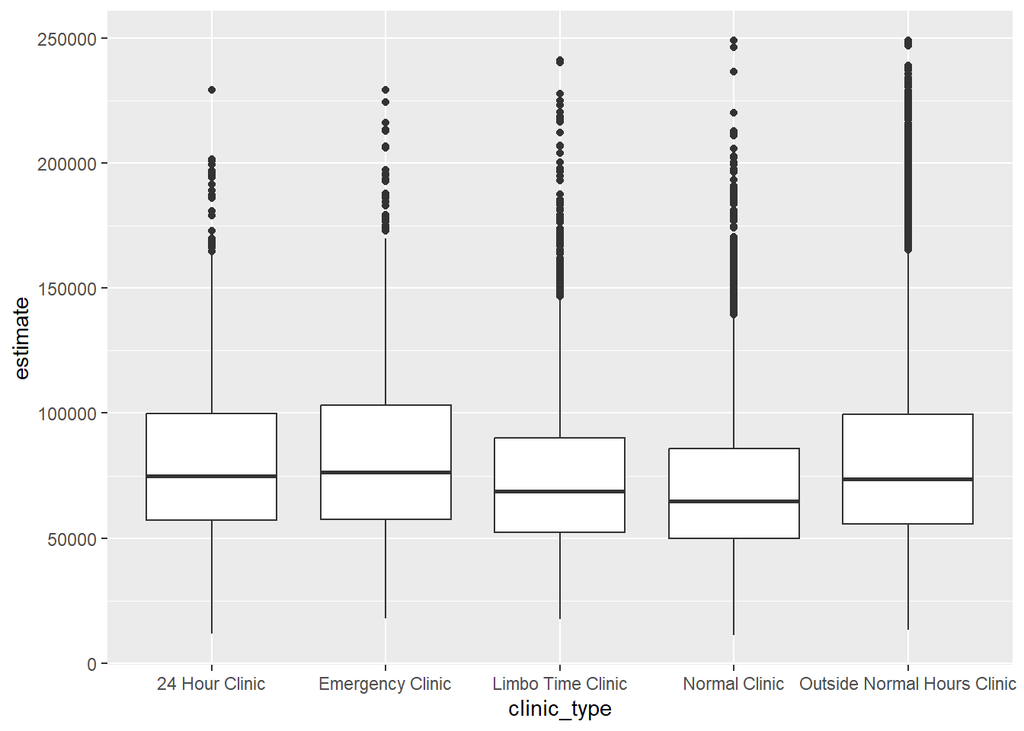

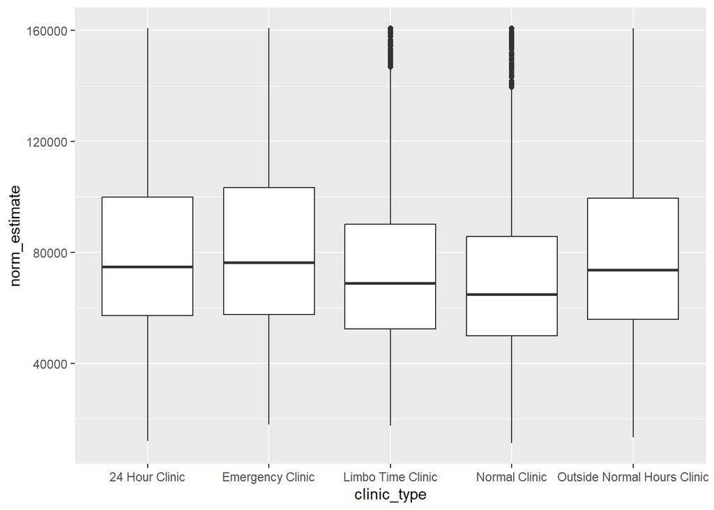

- Low Income Range = 11150 - 60257
- Medium Income Range = 60260 - 86875
- High Income Range = 86855 - 248929

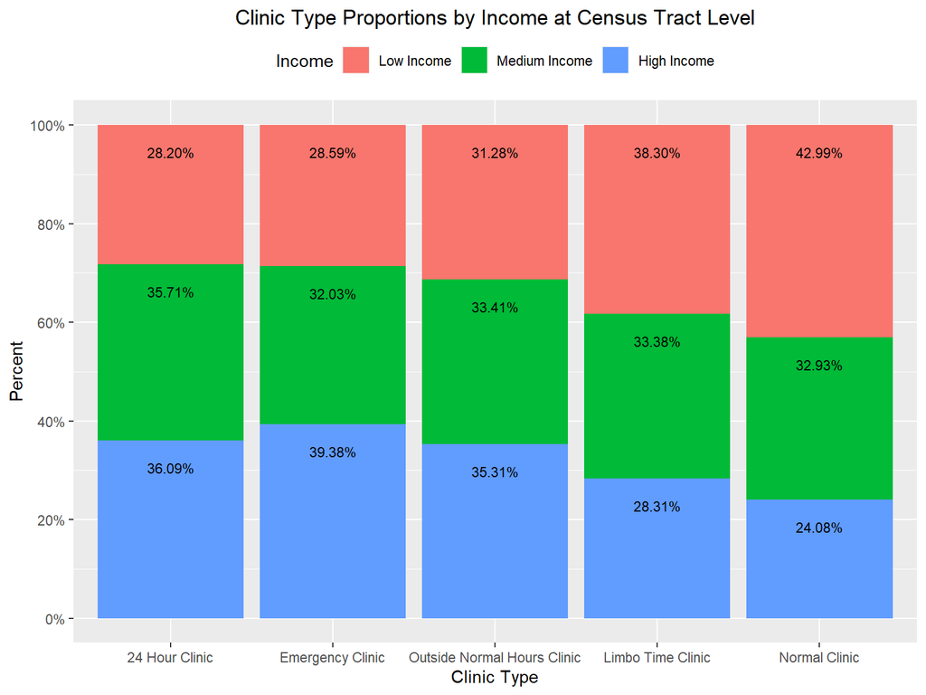

### Assumptions of Chi Square

- The data in each cell should be a count: CHECK
- The levels of the categories should be mutually exclusive. ie, no levels like, low income, low and medium income, low and medium and high income: CHECK
- Each subject may contribute data to one and only one cell: CHECK
- The study groups must be independent. ie, no paired samples like, pre and post test results: CHECK
- There are 2 variables, and both are measured as categories: CHECK
- The value of the cell expecteds should be 5 or more in at least 80% of the cells: CHECK

```
##
##                 24 Hour Clinic Emergency Clinic Limbo Time Clinic Normal Clinic
##   Low Income               293              474              1035          1350
##   Medium Income            371              531               902          1034
##   High Income              375              653               765           756
##
##                 Outside Normal Hours Clinic
##   Low Income                           4645
##   Medium Income                        4961
##   High Income                          5244
```

```
##
##                 24 Hour Clinic Emergency Clinic Limbo Time Clinic Normal Clinic
##   Low Income          346.3629         552.7139          900.7437      1046.756
##   Medium Income       346.4518         552.8557          900.9747      1047.025
##   High Income         346.1853         552.4304          900.2816      1046.219
##
##                 Outside Normal Hours Clinic
##   Low Income                       4950.423
##   Medium Income                    4951.693
##   High Income                      4947.884
```

```
##
##                 24 Hour Clinic Emergency Clinic Limbo Time Clinic Normal Clinic
##   Low Income       -3.59249424      -4.25424260        5.82567296   12.33752834
##   Medium Income     1.65252558      -1.18115690        0.04448576   -0.52987700
##   High Income       1.94011167       5.43617274       -5.87091488  -11.80913263
##
##                 Outside Normal Hours Clinic
##   Low Income                    -8.79909888
##   Medium Income                  0.26811006
##   High Income                    8.53206640
```

```
## [1] "pvalue"
```

```
## [1] 1.345281e-57
```

```
## Cramer V
##  0.07849
```

The first table is our observed values, second table is our expected, and the third is our standardized residuals. We can see from the expected values, that chisquare test expects each clinic to have about the same number of clinics in each group. I believe this is because we have an equal number of clinics in each of the income groups.

There is a very weak association between Income and clinic type.

### Scatter Plots

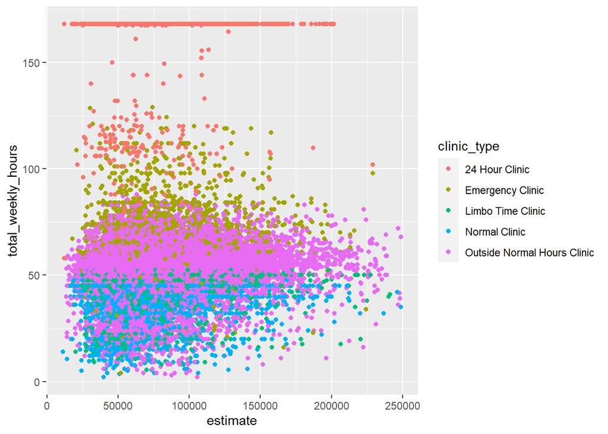

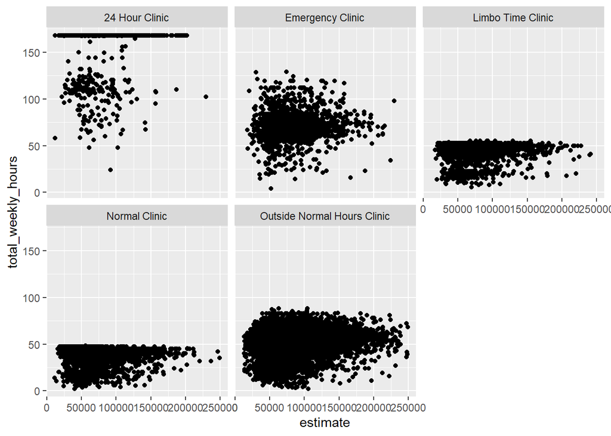

### County Level Analysis

[output not shown]

#### County Level Datatable

|  | column_name | min | mean | median | max | SD |
| --- | --- | --- | --- | --- | --- | --- |
| 1 | population_estimate | 64 | 105456.34 | 25698 | 10014009 | 335760 |
| 2 | median_income_estimate | 0 | 58217.18 | 55910 | 156821 | 15578 |
| 3 | median_income_moe | 0 | 4373.33 | 3601 | 34090 | 3043 |
| 4 | normal_clinic | 0 | 1.01 | 0 | 43 | 2 |
| 5 | limbo_time_clinic | 0 | 0.86 | 0 | 34 | 2 |
| 6 | outside_normal_hours_clinic | 0 | 4.75 | 1 | 304 | 14 |
| 7 | emergency_clinic | 0 | 0.53 | 0 | 68 | 2 |
| 8 | twenty_four_hour_clinic | 0 | 0.33 | 0 | 26 | 1 |
| 9 | clinics_with_no_hours | 0 | 2.64 | 1 | 208 | 8 |
| 10 | total_vet_clinics | 0 | 10.13 | 3 | 658 | 27 |

[output cut: 12 more lines]

#### Income Group Table

```
##
##    Low Income Medium Income   High Income
##           923          2152            68
```

```
## # A tibble: 3 × 3
##   income_group     min    max
##   <fct>          <dbl>  <dbl>
## 1 Low Income         0  49986
## 2 Medium Income  50000  99734
## 3 High Income   100292 156821
```

#### Percentages for Type of Care and Clinic Type

```
##
##                 Emergency Care Farm/Large Animal General/Primary    Low Cost
##   Low Income       0.008434864       0.019212746     0.950796626 0.006091846
##   Medium Income    0.019071910       0.025086604     0.901214359 0.011420305
##   High Income      0.019556334       0.026561588     0.883829539 0.007589025
##
##                 Mobile/Home Care Specialty Care
##   Low Income         0.009372071    0.006091846
##   Medium Income      0.015569683    0.027637139
##   High Income        0.020140105    0.042323409
```

```
##
##                 24 Hour Clinic Emergency Clinic Limbo Time Clinic Normal Clinic
##   Low Income        0.02882206       0.03258145        0.14661654    0.24436090
##   Medium Income     0.04446162       0.07109737        0.11664091    0.13158166
##   High Income       0.05667856       0.09353944        0.08561237    0.08600872
##
##                 Outside Normal Hours Clinic
##   Low Income                     0.54761905
##   Medium Income                  0.63621844
##   High Income                    0.67816092
```

#### Type of Care Chi Square with Income Group and Cramer V

```
##
##  Pearson's Chi-squared test
##
## data:  table(all_clinics_cleaned_with_hours$income_group, all_clinics_cleaned_with_hours$clinic_type_text)
## X-squared = 103.17, df = 10, p-value < 2.2e-16
```

```
## Cramer V
##  0.04026
```

#### Clinic Type Chi Square with Income Group and Cramer V

```
##
##  Pearson's Chi-squared test
##
## data:  table(all_clinics_cleaned_with_hours$income_group, all_clinics_cleaned_with_hours$clinic_type)
## X-squared = 316.99, df = 8, p-value < 2.2e-16
```

```
## Cramer V
##  0.08207
```

#### Income Group and Whether County has Clinic Chi Square and Cramer V

```
##
##                          0          1
##   Low Income    0.28494041 0.71505959
##   Medium Income 0.12128253 0.87871747
##   High Income   0.01470588 0.98529412
```

```
##
##  Pearson's Chi-squared test
##
## data:  table(county_level_dat$income_group, county_level_dat$has_clinic)
## X-squared = 135.94, df = 2, p-value < 2.2e-16
```

```
## Cramer V
##    0.208
```

#### Income Group Interesting Stats DT and Percent in Each State

|  | income_group | median_hours | total_clinics | total_area | median_pop | clinics_per_100SQMI |
| --- | --- | --- | --- | --- | --- | --- |
| 1 | Low Income | 45 | 2134 | 1024444.9 | 16826 | 0.21 |
| 2 | Medium Income | 141.75 | 26269 | 2476296.9 | 34128.5 | 1.06 |
| 3 | High Income | 1311.5 | 3426 | 32294.9 | 249504.5 | 10.61 |

|  | state_name | Low Income | Medium Income | High Income | low_income_percent | medium_income_percent | high_income_percent |
| --- | --- | --- | --- | --- | --- | --- | --- |
| 1 | Alabama | 39 | 28 | 0 | 4.23 | 1.3 | 0 |
| 2 | Alaska | 3 | 27 | 0 | 0.33 | 1.25 | 0 |
| 3 | Arizona | 5 | 10 | 0 | 0.54 | 0.46 | 0 |
| 4 | Arkansas | 58 | 17 | 0 | 6.279999999999999 | 0.79 | 0 |
| 5 | California | 3 | 48 | 7 | 0.33 | 2.23 | 10.29 |
| 6 | Colorado | 16 | 45 | 3 | 1.73 | 2.09 | 4.41 |
| 7 | Florida | 22 | 45 | 0 | 2.38 | 2.09 | 0 |
| 8 | Georgia | 84 | 73 | 2 | 9.1 | 3.39 | 2.94 |
| 9 | Idaho | 10 | 34 | 0 | 1.08 | 1.58 | 0 |
| 10 | Illinois | 12 | 88 | 2 | 1.3 | 4.09 | 2.94 |

[output cut: 41 more lines]

### Findings/Story

One of the stories I am seeing here is that while the type of clinic and type of care does not vary too much between the income groups, Almost all high income counties have a clinic while only 70% of the low income counties have a clinic. One has to travel a lot farther to get to a clinic than if one is living in a high income county. I performed a chi square test and a cramer v test on income group and type of care, type of clinics, and whether the county has a clinic or not. While all three were statistically significant, both type of care and type of clinic almost had no association between income group and type of care or type of clinic. However, income group and whether the county has at least one clinic had a cramer v score of 0.2 which I would classify as at least a weak association.

A large part of this is because higher income counties tend to have a denser population. With that being said, If the goal is for everyone, regardless of where they live, have access to a clinic, it is important that we understand what areas are showing a lack vet clinics and what types of clinics are they missing. Are there other ways of offering access to vet care to lower income and lower densely populated areas beside building clinics there. Perhaps setting up more mobile/at home clinics for basic care.

I believe there are recent articles explaining that lower income groups have a harder time paying for vet care. It is unfortunate these lower income areas also need to travel farther to access a vet clinic.

### In Progress…

#### Multiple Linear Regression and Logisical Regression

#### Variables for Multiple Linear Regression